# James’ manual

Dr. M. Dijkstra <m.dijkstra@cpb.nl>

Version: **dev-2020-10-21

> **Please beware** that browsers other than Chrome may not display this manual correctly. **Please note** that you are using the *development version* of James. This version may contain bugs and some features may be unimplemented. Therefore, this version comes with no guarantees. We advise you to use the [current version](https://confluence.cpb.nl/display/IENO/James) and ask the [Communication Department](https://confluence.cpb.nl/display/COM/CDS+medewerkers) help adapting your figure to the CPB-style, if needed.

# 1 A short introduction

This manual explains how to create customizable CPB-style figures with James from Excel and R. James’ goal is to tackle most of the CEP/MEV figures, which amounts mainly to customizable line and bar figures, scatter plots and fan charts - brightened up with some text labels. This novel version of James aims to

- bundle different settings in one parameter, which makes it easy to
  - change the dimensions of your figure (*e.g.* `style = wide`)
  - switch to English numbers and dates (`style = english`)
  - remove title or legend and extend the figure to that area (`style = no-title, no-legend`)
  - turn your figure to landscape (`turn = y`)
  - add a logo (`logo_show = y`)
- plot CBS-data in the CPB-style, just given an url (under development)
- make it easy to create a report
  - in *e.g.* html and pdf
  - out-of-the-box of all figures in one xlsx-file (see *e.g.* kMEV2021)
  - a custom report
- be faster than the previous version
- be easier to use than the previous version
  - below each figure in this manual is one line that explains how to reproduce it

## 1.1 What you need to know

The general workflow to create figures with James is:

1. **Copy the most recent *.bat (or* .sh) script from `M:/p_james/dev` to the path where you want to create figures.**
2. **Start the bat (or sh) file by by clicking on it.** This will:
   - process all `xlsx files` it sees.
   - give you a copy of the manual
   - create a subdirectory `generated/` with your figures

> The bat (or sh) file will warn you if you don’t make use of the latest and greatest version of the software.

So, how to start now? This manual recommends to first get some experience by running through the following section. Next, you can skip through this manual and find a figure with a style you like. Below that figure you’ll read how to recreate that figure. You can use that as a starting point and adapt it to your personal needs. Tip: use $<$Control$>$+F to quickly find terms in this manual.

# 2 A kick-start example

The following figure is a so-called ‘Hello World’ example. Directly below the figure you’ll find the instructions to reproduce it (in green).

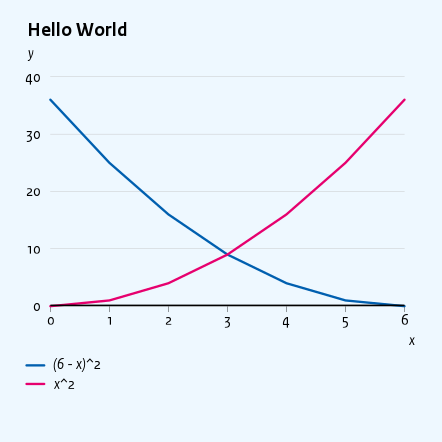

**Relevant parameters:**

| title | Hello World |
| --- | --- |
| x_title | x |
| y_title | y |

**How to reproduce this figure:** copy this xlsx-file and this batch file to a personal directory and start the batch file. You can also run this R-script in R.

## 2.1 A more realistic example

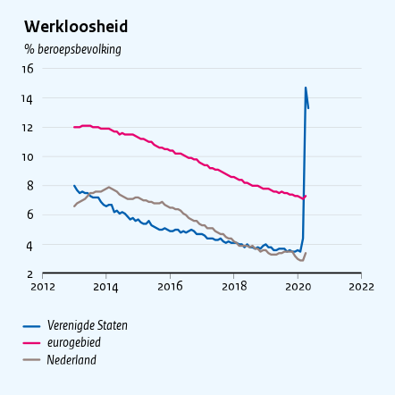

**Relevant parameters:**

| title | Werkloosheid |
| --- | --- |
| y_title | % beroepsbevolking |

**How to reproduce this figure:** copy this xlsx-file and this batch file to a personal directory and start the batch file. You can also run this R-script in R.

If you succeed to reproduce the above figure(s), you’re ready to learn more!

# 3 Figure type

Parameter `type` specifies how the time series should appear in your figure. If you leave parameter `type` empty, it will default to `type = line`. If you specify only one value (*e.g.* `type = bar--`), James will use that value for each of the time series in your data. If want to mix different types, then you should specify the type for each of your time series. In which case the `type`’s `i`’t element corresponds to the `i`’th time series in your data. In particular, time series that are described with two columns of data (*e.g.* fan/bandwidth/area and whiskers), also need two values for parameter `type`.

> Parameter `type` must have either zero values, one value, or *n* values. In case of zero values it defaults to `line` for all time series. In case of one value, this type will be used for all time series in your data. Otherwise, *n* should equal the number of time series columns in your data (*i.e.* all, exclusive the *x*-axis).

## 3.1 Line

Section A kick-start example shows how to create a line figure with two series. Implicitely, the parameter `type = line` (or `type = line, line`) is set there.

Some examples of figures with lines: Two bandwiths in one plot, Oversterfte in 2020, Decompositie gemiddelde marginale belastingdruk werknemers 2021 , Groeibijdragen bestedingen, Koopkrachtontwikkeling, Koopkrachtontwikkeling, Economische groei in Nederland.

### 3.1.1 Line with discontinuity

A discontinuity works as follows. The data for the x-axis, in the first column of your xlsx-file, needs values everywhere. So, you should provide an *x*-value at the position where you want the discontinuity. You can leave the cell, which corresponds to the position of the discontinuity in the respective series, empty. Please look at the xlsx-file (link below figure) to see how that’s done here. This example also shows how to put multiple variants of the same series in the same plot.

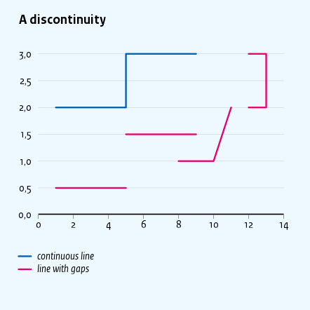

You can take a look at the xlsx-file to see how this is done.

**Relevant parameters:**

| title | A discontinuity |
| --- | --- |
| y_lim | 0, 3 |

**How to reproduce this figure:** copy this xlsx-file and this batch file to a personal directory and start the batch file. You can also run this R-script in R.

### 3.1.2 Dashed lines

Next to the default ‘solid’ line (*i.e.* `line_lty``= 1`) there are five other line types you can choose from. The order of the values you give to a parameter corresponds to the order of the lines. So, the first value corresponds to the first line, the second value to the second line, etc.

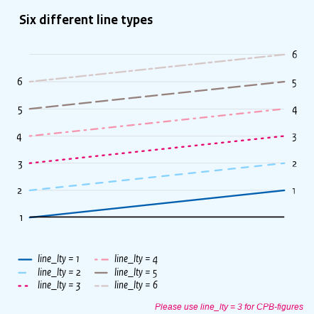

**Relevant parameters:**

| style | y-right |
| --- | --- |
| title | Six different line types |
| y_lab | 1; 2; 3; 4; 5; 6; |
| footnote | Please use line_lty = 3 for CPB-figures |
| footnote_col | rose |
| x_lim_follow_data | y |
| line_lty | 1, 2, 3, 4, 5, 6 |
| y_r_lab | ; 1; 2; 3; 4; 5; 6 |
| x_axis_show | n |

**How to reproduce this figure:** copy this xlsx-file and this batch file to a personal directory and start the batch file. You can also run this R-script in R.

### 3.1.3 Line with symbol (*e.g.* dot)

You can decorate your line with dots, diamonds or other symbols. This figure shows the available symbols. The symbols are superimposed at the data points you provide in your data tab. An example:

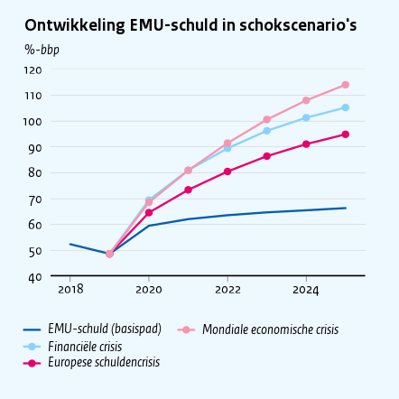

**Relevant parameters:**

| title | Ontwikkeling EMU-schuld in schokscenario’s |
| --- | --- |
| y_title | %-bbp |
| x_lim | 2017.5, 2025.5 |
| line_symbol | 0, 20, 20, 20 |

**How to reproduce this figure:** copy this xlsx-file and this batch file to a personal directory and start the batch file. You can also run this R-script in R.

The following example adds a ‘rose’-colored diamond to the second time series. The diamond is automatically added to the legend too.

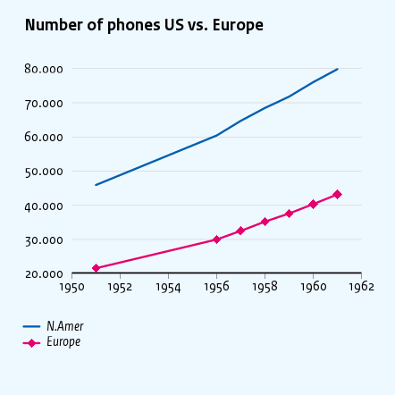

**Relevant parameters:**

| title | Number of phones US vs. Europe |
| --- | --- |
| order | 1, 2 |
| line_symbol | 0, 18 |
| line_symbol_col | NA, rose |
| tab | NA |

**How to reproduce this figure:** copy this xlsx-file and this batch file to a personal directory and start the batch file. You can also run this R-script in R.

### 3.1.4 Parameters to tweak your lines

You can use the following parameters to customize lines. Please beware that the order of the values you give to a parameter corresponds to the order of the lines; *i.e.*, not necessarily to the order of the time series if some of them are not lines. So, the first value corresponds to the first line, the second value to the second line, etc.

- **`line_lty`**: line type (1: continuous; 2, 3, … have dashes). For dashes the advice is to use 3. Please beware that the forecasted part of a line is automatically dashed, unless you specify this parameter. The value is a list with elements of the type ‘numeric’ separated by ‘,’. Example(s): `1, 1, 3, 1 if the third line is dashed`. For the *default* style the value is `1`. See also parameter(s): line_obs_fc_lty. Figure(s) using ‘line_lty’: Six different line types, Two bandwiths in one plot, Oversterfte in 2020, Groeibijdragen bestedingen, trend-vs-niveau.
- **`line_lwd`**: time series line width. The value is a list with elements of the type ‘numeric’ separated by ‘,’. For the *default* style the value is `1.5`.
- **`line_symbol`**: add a symbol to your line. This may be e.g. a dot (1, 19, 20) or a diamond (18). The symbol will be added at the data points that define your line. The value is a list with elements of the type ‘numeric’ separated by ‘,’. Example(s): `0, 1, 2, …, 23`. For the *default* style the value is `0`. See also parameter(s): dot_shape. Figure(s) using ‘line_symbol’: Ontwikkeling EMU-schuld in schokscenario’s.
- **`line_symbol_col`**: color of the symbols that decorate your line. The colors default to the line color. The value is a list with elements of the type ‘string’ separated by ‘,’. Example(s): `endeavour, anakiwa, rose, mauvelous, brown, cold_turkey, siren, biscay, dorado, sun`.
- **`line_symbol_size`**: size of symbol. The value is a list with elements of the type ‘numeric’ separated by ‘,’. For the *default* style the value is `1`.

## 3.2 Bar

Bars can be next to each other (`type = bar--`) or stacked (`type = bar=`) or a combination of the two.

### 3.2.1 Bars next to each other

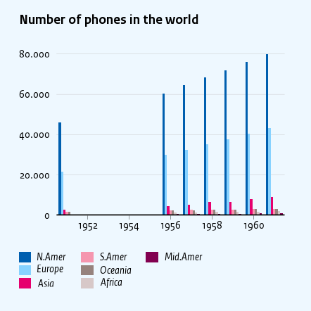

**Relevant parameters:**

| type | bar– |
| --- | --- |
| title | Number of phones in the world |
| tab | NA |

**How to reproduce this figure:** copy this xlsx-file and this batch file to a personal directory and start the batch file. You can also run this R-script in R.

In this example there is no data given for years 1952 … 1955. Therefore, you see a ‘gap’ between the subsequent sets of bars. The figure, however, could suggest that there were no phones in those years. To circumvent this issue, you can consider to tell James that the values on the x-axis are ‘words’. James does not interpret their value then and just puts them equidistant on the *x*-axis – as can be seen in the following example.

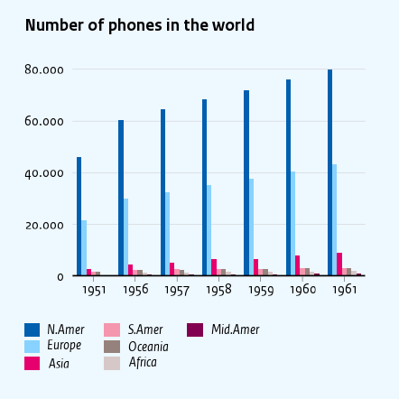

**Relevant parameters:**

| type | bar– |
| --- | --- |
| title | Number of phones in the world |
| x_lab_as_text | y |
| tab | NA |

**How to reproduce this figure:** copy this xlsx-file and this batch file to a personal directory and start the batch file. You can also run this R-script in R.

List of figures with bars next to each other: NA, Europese steunpakketten, VWO, VWO, VWO, Impact no-deal Brexit (horizontal), Impact no-deal Brexit (tall), VMBO, Verwacht verlies in verschillende scenario’s, Economische groei in Nederland.

### 3.2.2 Bars stacked

Type `bar=` stacks bars.

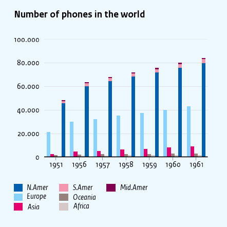

**Relevant parameters:**

| type | bar=, bar–, bar–, bar=, bar–, bar–, bar= |
| --- | --- |
| title | Number of phones in the world |
| x_lab_as_text | y |
| tab | NA |

**How to reproduce this figure:** copy this xlsx-file and this batch file to a personal directory and start the batch file. You can also run this R-script in R.

Parameter `bar_stack_index` determines the positions of the stacks. By default they are shown at the right hand side. The figure below sets `bar_stack_index = 1` and moves the stacks to the left. It also sets a name for the stack and adds it to the legend by with `bar_stack_name = "The Americas"`.

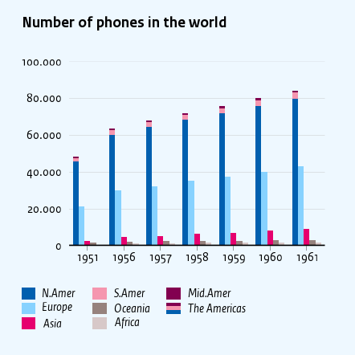

**Relevant parameters:**

| type | bar=, bar–, bar–, bar=, bar–, bar–, bar= |
| --- | --- |
| title | Number of phones in the world |
| x_lab_as_text | y |
| bar_stack_name | The Americas |
| bar_stack_index | 1 |
| tab | NA |

**How to reproduce this figure:** copy this xlsx-file and this batch file to a personal directory and start the batch file. You can also run this R-script in R.

List of figures with stacked bars: Decompositie gemiddelde marginale belastingdruk werknemers 2021 , Investeringen in Nederland¹ door de zwaarst-eurolanden in 2018 en vice versa, Groeibijdragen bestedingen, Verlies van banken na afschrijving 20% van devan GIIPS-landen.

### 3.2.3 Dealing with many bars

The visualization of many bars in one figure may be a challenge. Opting for a wide figure (`style = wide`) obviously helps to create more space. In addition one can play with `bar_gap_fraction`, here set to 0.5 in the figure below so the size of the whitespace between the bars is balanced with the width of the bars. To ensure that the line is not submerged by the bars, the line is highlighted.

The author uses `x_scale` because the *x*-values where given in thousands of euros and the author wants just euros on the *x*-axis. Putting `x_lab_big_mark_show``= y` adds a thousands separator so large numbers are easier to read.

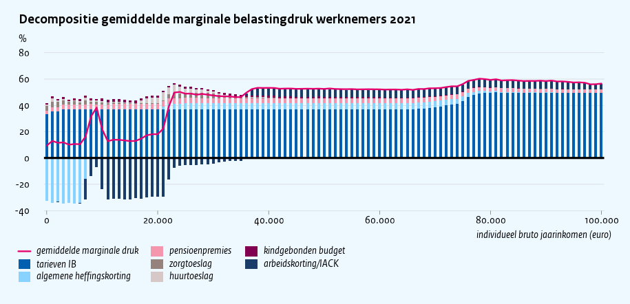

**Relevant parameters:**

| [style](https://dont-remove-this) | wide |
| --- | --- |
| [type](https://dont-remove-this) | line, bar=, bar=, bar=, bar=, bar=, bar=, bar= |
| [title](https://dont-remove-this) | Decompositie gemiddelde marginale belastingdruk werknemers 2021 |
| [x_title](https://dont-remove-this) | individueel bruto jaarinkomen (euro) |
| [y_title](https://dont-remove-this) | % |
| [highlight_series](https://dont-remove-this) | 1 |
| [bar_gap_fraction](https://dont-remove-this) | 0.5 |
| [x_scale](https://dont-remove-this) | 1000 |
| [x_lab_big_mark_show](https://dont-remove-this) | y |

**How to reproduce this figure:** copy this xlsx-file and this batch file to a personal directory and start the batch file. You can also run this R-script in R.

### 3.2.4 Group data

One can group data points. Dependent on the orientation of the plot (`turn = y` or `turn = n`), the groups are shown in a different manner.

#### 3.2.4.1 Vertical grouping

The following example shows how you can ‘manually’ group data points. Please note the zero that was added to the data (below the figure is a link to the xlsx-file). The zero creates space between the groups. In addition, *y*-axis, which is now the *x*-axis because `turn = y` starts at zero. If you don’t want this number (here: 0) to affect your axis, you can choose a value in between the range of the other values.

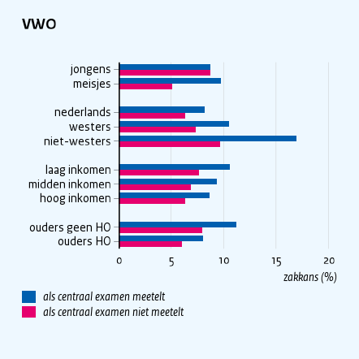

**Relevant parameters:**

| type | bar– |
| --- | --- |
| title | VWO |
| y_title | zakkans (%) |
| turn | y |
| x_ticks | 1, 2, 4, 5, 6, 8, 9, 10, 12, 13 |

**How to reproduce this figure:** copy this xlsx-file and this batch file to a personal directory and start the batch file. You can also run this R-script in R.

In the xlsx-file you can add group names in a column preceding your data:

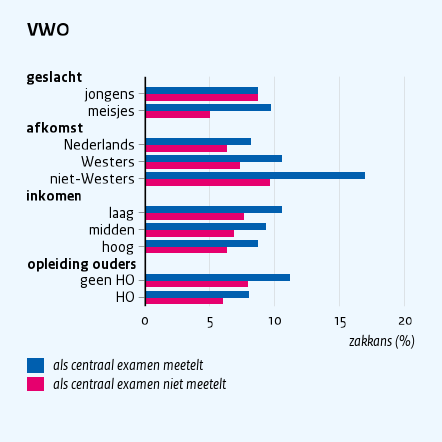

**Relevant parameters:**

| type | bar– |
| --- | --- |
| title | VWO |
| y_title | zakkans (%) |
| turn | y |
| hline_bold | 0 |

**How to reproduce this figure:** copy this xlsx-file and this batch file to a personal directory and start the batch file. You can also run this R-script in R.

#### 3.2.4.2 Horizontal grouping

For horizontal grouping, you can use parameter `group_spacing` if you want to add some extra space between the groups. This parameter also works for vertical grouping but may be less needed there.

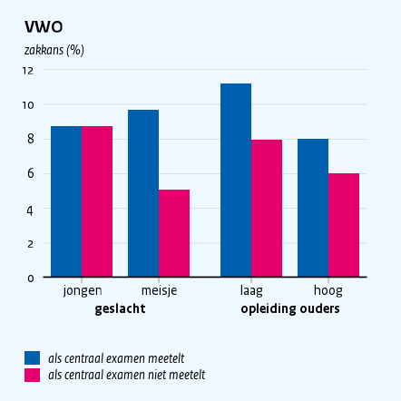

**Relevant parameters:**

| type | bar– |
| --- | --- |
| title | VWO |
| y_title | zakkans (%) |
| hline_bold | 0 |
| legend_y | 0.8 |
| group_spacing | 0.2 |

**How to reproduce this figure:** copy this xlsx-file and this batch file to a personal directory and start the batch file. You can also run this R-script in R.

Another example of horizontal grouping is the following figure. The `x_title` is shifted lower with `x_title_v_shift` and used to add a kind of extra footnote refering to the title (using ¹). The legend is shifted higher with `legend_y` and put on one line with `legend_n_per_column` to make space for it. In addition `x_lab_font_size` scales the font size of labels at the *x*-axis somewhat smaller.

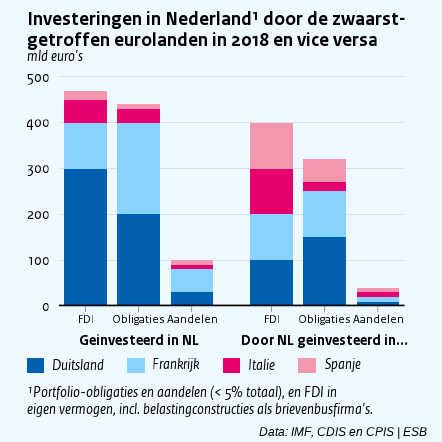

**Relevant parameters:**

| type | bar= |
| --- | --- |
| title | Investeringen in Nederland¹ door de zwaarst-eurolanden in 2018 en vice versa |
| x_title | ¹Portfolio-obligaties en aandelen (< 5% totaal), en FDI invermogen, incl. belastingconstructies als brievenbusfirma’s. |
| y_title | mld euro’s |
| footnote | Data: IMF, CDIS en CPIS \| ESB |
| legend_n_per_column | 1 |
| legend_y | 1.3 |
| group_spacing | 0.5 |
| x_title_v_shift | 1.6 |
| x_lab_font_size | 0.85 |
| x_title_align | left |

**How to reproduce this figure:** copy this xlsx-file and this batch file to a personal directory and start the batch file. You can also run this R-script in R.

#### 3.2.4.3 Tailor groups

- **`first_col_grouping`**: bars can be grouped. Doing so, gives bars in the same group a common ‘header’. Put group names in the first column, left of the time series names. Time series that belong to the same group should get the same group name. If both one of the group names and one of the time series names contains at least one character (a non-numeric value), first_col_grouping will be set to `y` automatically. Otherwise, you can do so by hand. The value is of type ‘bool’.
- **`first_row_grouping`**: boxes can be grouped, which gives the boxes in the same group the same ‘header’ (and the same color if you want to). Put group names in the first row, above the time series names. If these comprise characters, first_row_grouping will be set to `y` automatically. The value is of type ‘bool’.
- **`group`**: names of groups. If given, number of elements should equal number of time series. The value is a list with elements of the type ‘string’ separated by ‘;;’. Example(s): `group-1;; group-2;; group-2`. See also parameter(s): first_row_grouping, box_col_per_group, name.
- **`group_col`**: not documented yet. The value is of type ‘string’. For the *default* style the value is `black`.
- **`group_font`**: 1 = normal, 2 = bold, 3 = italic, 4 = bold and italic. The value is of type ‘numeric’. Example(s): `1, 2, 3, 4`. For the *default* style the value is `2`.
- **`group_font_size`**: not documented yet. The value is of type ‘numeric’. For the *default* style the value is `1`.
- **`group_spacing`**: extra space between groups. The value is of type ‘numeric’. Example(s): `0, 0.5, 1, 2`. For the *default* style the value is `0`. Figure(s) using ‘group_spacing’: VWO, Investeringen in Nederland¹ door de zwaarst-eurolanden in 2018 en vice versa.
- **`group_x`**: the x-positions of the group names. James will set them automatically if not specified by user. Please beware that the group names should be placed at different positions, dependent on the orientation of your plot (*i.e.*, `turn = y` or `turn = n`). The value is a list with elements of the type ‘numeric’ separated by ‘,’.
- **`labels_margin_add_for_groups`**: minimal distance between `group` name and series name. The value is of type ‘numeric’. Unit: ‘cm’. For the *default* style the value is `0`.
- **`x_lab_group_v_shift`**: downshift of the group-labels below the x-axis. The value is of type ‘numeric’. Unit: ‘cm’. For the *default* style the value is `0.5`.

### 3.2.5 Highlight a specific series

In general, parameter `highlight_series` will give color `highlight_col` (default: rose) to that series. *I.e.*, also for non-bar type figures.

The following figure, for example, highlights the second time series.

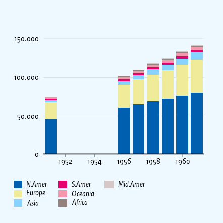

**Relevant parameters:**

| type | bar= |
| --- | --- |
| highlight_series | 2 |
| highlight_col | yellow |
| tab | NA |

**How to reproduce this figure:** copy this xlsx-file and this batch file to a personal directory and start the batch file. You can also run this R-script in R.

If you use this parameter to highlight a time series of type ‘bar’ (`bar--` or `bar=`), you can choose to limit the highlighting to one bar in particular. The following figure shows how you can do so with parameter `highlight_x`.

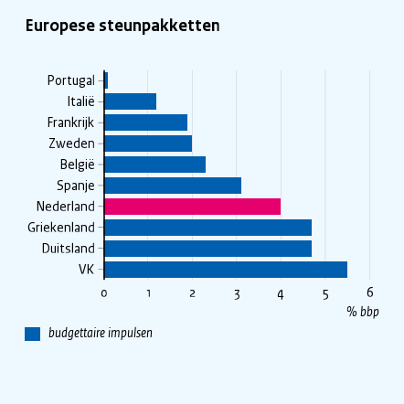

**Relevant parameters:**

| type | bar– |
| --- | --- |
| title | Europese steunpakketten |
| y_title | % bbp |
| turn | y |
| highlight_series | 1 |
| highlight_x | 7 |

**How to reproduce this figure:** copy this xlsx-file and this batch file to a personal directory and start the batch file. You can also run this R-script in R.

#### 3.2.5.1 Tailor your highlighting

Please note that if the ‘highlight color’ is part of your palette, which the default highlight color is, it will be removed from the palette so that only the highlighted time series gets the wanted color.

These parameters enable you to highlight a certain time series or a certain bar of a certain time series.

- **`highlight_col`**: for highlighting a time series. The value is of type ‘string’. Example(s): `#ffa500`. For the *default* style the value is `rose`.
- **`highlight_series`**: time series you want to highlight. The value is of type ‘numeric’. Figure(s) using ‘highlight_series’: Europese steunpakketten, Decompositie gemiddelde marginale belastingdruk werknemers 2021 , Verlies van banken na afschrijving 20% van devan GIIPS-landen.
- **`highlight_x`**: if you want to highlight a time series of type ‘bar’, with this parameter you can narrow the highlight to only one given x-position. The x-position specified here, is interpreted as a number (only if all values on the x-axis are numbers) or as a string (if at least one of the values on the x-axis is a string). The value is of type ‘numeric’. Unit: ‘x’. Example(s): `bbp`. Figure(s) using ‘highlight_x’: Europese steunpakketten.

### 3.2.6 Parameters to tailor your bar plot

- **`bar_gap_fraction`**: how much space you want between the bars of two consecutive x-points, where 0 means no gap, 1 means no bars. The value is of type ‘numeric’. Unit: ‘fraction’. Example(s): `0, 0.1`. For the *default* style the value is `0.2`. Figure(s) using ‘bar_gap_fraction’: Decompositie gemiddelde marginale belastingdruk werknemers 2021 .
- **`bar_lab_big_mark_show`**: for the values in or above bars, use `y` if you want a character between every three digits left of the decimal separator. The value is of type ‘bool’. Example(s): `y, n`. For the *default* style the value is `y`.
- **`bar_lab_col`**: color of the labels. The value is of type ‘string’. For the *default* style the value is `black`.
- **`bar_lab_font_size`**: leave empty for auto scaling. The value is of type ‘numeric’.
- **`bar_lab_font_style`**: 1 = normal, 2 = bold, 3 = italic, 4 = bold and italic. The value is of type ‘numeric’. Example(s): `1, 2, 3, 4`. For the *default* style the value is `1`.
- **`bar_lab_increase_y_lim_2`**: add extra space for labels above bars. The value is of type ‘numeric’. Unit: ‘fraction of y_lim’. For the *default* style the value is `0.2`.
- **`bar_lab_n_decimals`**: the number of decimals the bar labels should get. The value is of type ‘numeric’. For the *default* style the value is `0`.
- **`bar_lab_rotation`**: rotate the barplot labels. Zero (0) for horizontal. 90 for vertical. Leave empty for default (horizontal for labels on top of the bars, vertical for labels inside the bars). The value is of type ‘numeric’. Unit: ‘degrees’. Example(s): `0, 90`. For the *default* style the value is `do-not-change`.
- **`bar_lab_show`**: you can show the value of the bar on top of it, or in its middle. The value is of type ‘bool’. For the *default* style the value is `n`. Figure(s) using ‘bar_lab_show’: kansrijk.
- **`bar_lab_top`**: `y` means top, `n` means middle. The value is of type ‘bool’. Example(s): `y, n`. For the *default* style the value is `y`.
- **`bar_stack_index`**: the position where the stacked bars should appear if you also have bars next to each other. Default is at the right. The value is of type ‘numeric’.
- **`bar_stack_name`**: name that explains what the sum of the stacked bars means. The value is of type ‘string’.

## 3.3 Scatter plot, adding symbols

This section shows how to add dots (more generic: symbols) to your plot. The following parameters help to fine-tune the dots to your needs.

Dots can have different shapes and sizes. Probably, ‘symbol’ would be a more appropriate name for this variable.

- **`dot_lwd`**: line width for drawing symbols such as dots/diamonds. The value is a list with elements of the type ‘numeric’ separated by ‘,’. For the *default* style the value is `1`.
- **`dot_shape`**: there are over 20 symbols you can choose from; they are all shown in one of the figures in the manual. There are two types of alternatives to the shapes. Firstly, you can use ‘.’ (a period) to specify very small dots. Secondly, you can use a single character (e.g. a letter, digit or sign (e.g. a, 1, or %)). The value is a list with elements of the type ‘numeric’ separated by ‘,’. For the *default* style the value is `19`. Figure(s) using ‘dot_shape’: Koopkrachtontwikkeling, Koopkrachtontwikkeling, Verlies van banken na afschrijving 20% van devan GIIPS-landen.
- **`dot_size`**: size of symbol, c.q. dot. The value is a list with elements of the type ‘numeric’ separated by ‘,’. For the *default* style the value is `1`. Figure(s) using ‘dot_size’: Koopkrachtontwikkeling, Overlapping labels (NL, PT), Different alignment for PT, Verwacht verlies in verschillende scenario’s, Verwacht verlies in verschillende scenario’s.

List of figures with dots: Koopkrachtontwikkeling, Koopkrachtontwikkeling, Verlies van banken na afschrijving 20% van devan GIIPS-landen, Overlapping labels (NL, PT), Different alignment for PT, Verwacht verlies in verschillende scenario’s, Verwacht verlies in verschillende scenario’s.

### 3.3.1 Scatter plot

Example of a scatter plot:

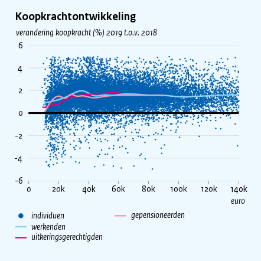

**Relevant parameters:**

| type | dot, line, line, line |
| --- | --- |
| title | Koopkrachtontwikkeling |
| x_title | euro |
| y_title | verandering koopkracht (%) 2019 t.o.v. 2018 |
| hline_bold | 0 |
| dot_shape | 20 |
| dot_size | 0.1 |
| x_at | 0, 20000, 40000, 60000, 80000, 1e+05, 120000, 140000 |
| x_lab | 0; 20k; 40k; 60k; 80k; 100k; 120k; 140k |

**How to reproduce this figure:** copy this xlsx-file and this batch file to a personal directory and start the batch file. You can also run this R-script in R.

Same plot but with smaller dots (`dot_shape = .`):

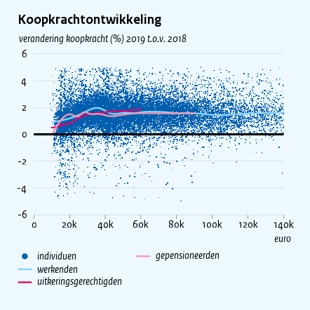

**Relevant parameters:**

| type | dot, line, line, line |
| --- | --- |
| title | Koopkrachtontwikkeling |
| x_title | euro |
| y_title | verandering koopkracht (%) 2019 t.o.v. 2018 |
| hline_bold | 0 |
| dot_shape | . |
| x_at | 0, 20000, 40000, 60000, 80000, 1e+05, 120000, 140000 |
| x_lab | 0; 20k; 40k; 60k; 80k; 100k; 120k; 140k |

**How to reproduce this figure:** copy this xlsx-file and this batch file to a personal directory and start the batch file. You can also run this R-script in R.

### 3.3.2 Different shapes of the dot/symbol

The following figure shows the different symbols you can choose from.

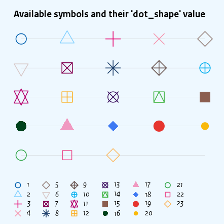

As an alternative to the above 23 shapes, you can also use a dot (`dot_shape = .` or equivalently `dot_shape = 46`) and letters as symbol shape. Value `.` is handled specially. It is a rectangle of side 0.01 inch = 0.0254 cm (scaled by `dot_size`). In addition, if `dot_size = 1` (the default), each side is at least one pixel (1/72 inch on the pdf).

### 3.3.3 Real world example

The figure below demonstrates `dot_shape = 18`. The ‘dots’ are highlighted with default color `highlight_col = rose`. If that color is part of your palette (which it is here!), it will be automatically removed from the palette so that only the highlighted time series gets the desired color.

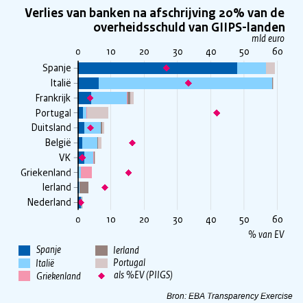

**Relevant parameters:**

| style | x-top |
| --- | --- |
| type | bar=, bar=, bar=, bar=, bar=, dot |
| title | Verlies van banken na afschrijving 20% van devan GIIPS-landen |
| y_title | % van EV |
| footnote | Bron: EBA Transparency Exercise |
| scale | 1, 1, 1, 1, 1, 100 |
| turn | y |
| y_axis | r, r, r, r, r, l |
| y_right_title | mld euro |
| highlight_series | 6 |
| dot_shape | 18 |
| y_at | 0, 10, 20, 30, 40, 50, 60 |

**How to reproduce this figure:** copy this xlsx-file and this batch file to a personal directory and start the batch file. You can also run this R-script in R.

## 3.4 Area/bandwidth/confidence interval/fan

The two subsections below describe how to visualize your time series as an area, bandwidth and fan.

### 3.4.1 Stacked areas

Parameter `type = area=` stacks the time series in your plot as areas, starting at the *x*-axis; *i.e.* the *y*-axis includes *y* = 0 by default. Parameter `area_stack_name` enables you to label the stack in the legend. An example of which is shown in the following figure. Please note that by default the `area_stack_name` is placed last in the legend; *i.e.* at position 4. To achieve the same vertical order in the legend as in the figure and keeping the `area_stack_name` last, parameter `legend_order` `= 3, 2, 1, 4`.

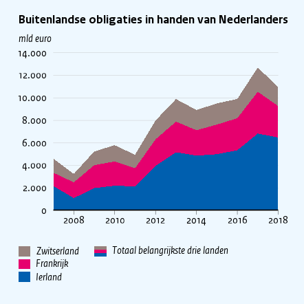

**Relevant parameters:**

| type | area= |
| --- | --- |
| title | Buitenlandse obligaties in handen van Nederlanders |
| y_title | mld euro |
| scale | 100 |
| x_lim_follow_data | y |
| legend_order | 3, 2, 1, 4 |
| area_stack_name | Totaal belangrijkste drie landen |

**How to reproduce this figure:** copy this xlsx-file and this batch file to a personal directory and start the batch file. You can also run this R-script in R.

List of figures with stacked areas: Buitenlandse obligaties in handen van Nederlanders .

### 3.4.2 Bandwidths

This subsection describes how you can plot an area without stacking it on another area. A non-stacked area has a bottom and a top. So, you’ll need two series of data to describe one area. These series you can mark with `type = area, area`, consecutively.

The following figure shows two lines with a confidence interval. The color palette is chosen so it’s clear to which line the interval belongs.

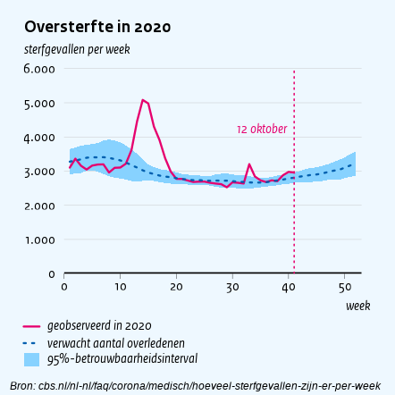

**Relevant parameters:**

| type | line, line, area, area |
| --- | --- |
| title | Oversterfte in 2020 |
| x_title | week |
| y_title | sterfgevallen per week |
| footnote | Bron: cbs.nl/nl-nl/faq/corona/medisch/hoeveel-sterfgevallen-zijn-er-per-week |
| x_lim | 0, 53 |
| line_lty | 1, 3 |
| hline_bold | 0 |
| vline_dash | 41 |
| vline_dash_col | rose |
| text_x | 42 |
| text_y | 4200 |
| text_pos | 2 |
| text_label | 12 oktober |
| text_col | rose |
| palette | rose, endeavour, anakiwa |

**How to reproduce this figure:** copy this xlsx-file and this batch file to a personal directory and start the batch file. You can also run this R-script in R.

One figure can hold more than one bandwidths:

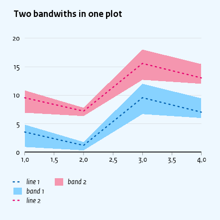

**Relevant parameters:**

| type | line, area, area, line, area, area |
| --- | --- |
| title | Two bandwiths in one plot |
| line_lty | 3, 3 |

**How to reproduce this figure:** copy this xlsx-file and this batch file to a personal directory and start the batch file. You can also run this R-script in R.

### 3.4.3 A standard fan plot

A ‘fan plot’ is a special case of bandwidth plot. It always follows one and the same structure: one line, followed by three confidence intervals with fixed colors. Parameter `style``= fan` initializes three parameters. Firstly, parameter `palette` for colors, secondly parameter `type` for the time series types conform the CPB style. *I.e.*, first a rose line, followed by three blue intervals with increasing intensities. This figure shows the color palette. You can re-use these colors in the case you want to customize your fan chart. Thirdly, the four items in the legend are put in one and the same column (`legend_n_per_column = 4`).

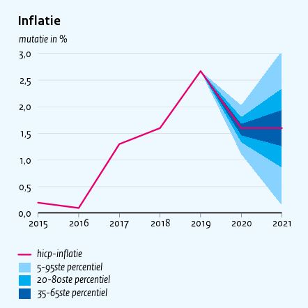

**Relevant parameters:**

| style | fan |
| --- | --- |
| title | Inflatie |
| y_title | mutatie in % |

**How to reproduce this figure:** copy this xlsx-file and this batch file to a personal directory and start the batch file. You can also run this R-script in R.

### 3.4.4 Parameters to tweak your area plots

TODO

## 3.5 Box plot

The default [box plot](https://en.wikipedia.org/wiki/Box_plot) in James shows quantities `box_quantiles = 0, 0.25, 0.5, 0.75, 1`.

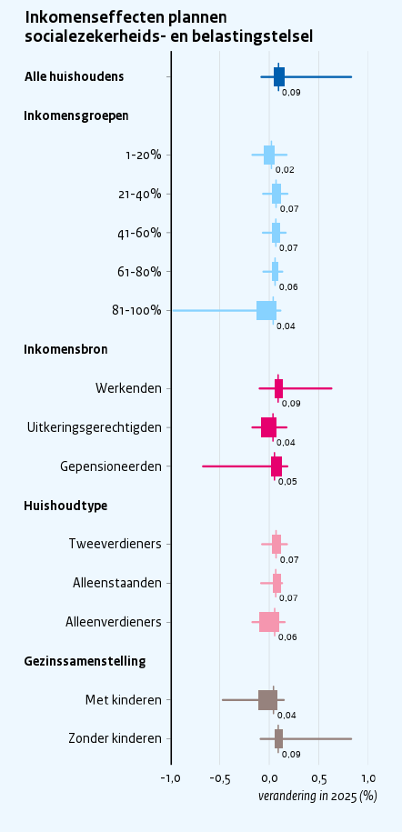

**Relevant parameters:**

| style | box-plot, no-legend, tall |
| --- | --- |
| type | box |
| title | Inkomenseffecten plannen- en belastingstelsel |
| y_title | verandering in 2025 (%) |
| turn | y |

**How to reproduce this figure:** copy this xlsx-file and this batch file to a personal directory and start the batch file. You can also run this R-script in R.

The following figure is an example how to adjust the box plot.

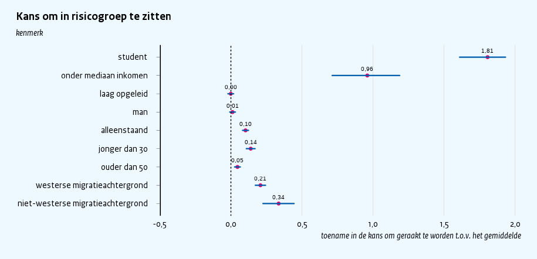

**Relevant parameters:**

| [style](https://dont-remove-this) | no-legend, wide |
| --- | --- |
| [type](https://dont-remove-this) | box |
| [title](https://dont-remove-this) | Kans om in risicogroep te zitten |
| [x_title](https://dont-remove-this) | kenmerk |
| [y_title](https://dont-remove-this) | toename in de kans om geraakt te worden t.o.v. het gemiddelde |
| [turn](https://dont-remove-this) | y |
| [box_col_all_equal](https://dont-remove-this) | y |
| [box_quantiles](https://dont-remove-this) | 0.025, 0.5, 0.5, 0.5, 0.975 |
| [box_median_shape](https://dont-remove-this) | 19 |
| [box_median_col](https://dont-remove-this) | rose |
| [hline_dash](https://dont-remove-this) | 0 |
| [box_median_lab_show](https://dont-remove-this) | y |
| [box_median_lab_n_decimals](https://dont-remove-this) | 2 |

**How to reproduce this figure:** copy this xlsx-file and this batch file to a personal directory and start the batch file. You can also run this R-script in R.

List of box-plot figures: Inkomenseffecten plannen- en belastingstelsel, Kans om in risicogroep te zitten.

### 3.5.1 Tailor your box plot

- **`box_col_all_equal`**: if `y`, all boxes get the same color. The value is of type ‘bool’. For the *default* style the value is `n`. Figure(s) using ‘box_col_all_equal’: Kans om in risicogroep te zitten.
- **`box_col_per_group`**: usually you want one color per group (`y`). But you may choose to give each box its own color. The value is of type ‘bool’. For the *default* style the value is `y`.
- **`box_gap_fraction`**: not documented yet. The value is of type ‘numeric’. For the *default* style the value is `0.2`. For the *box-plot* style the value is `0.5`.
- **`box_lab_big_mark_show`**: for the values (e.g. median) in box plots, use `y` if you want a character between every three digits left of the decimal separator. The value is of type ‘bool’. Example(s): `y, n`. For the *default* style the value is `y`.
- **`box_median_col`**: if empty, same color as box. The value is of type ‘string’. Example(s): `gray30`. Figure(s) using ‘box_median_col’: Kans om in risicogroep te zitten.
- **`box_median_lab_font_size`**: not documented yet. The value is of type ‘numeric’. For the *default* style the value is `0.7`.
- **`box_median_lab_n_decimals`**: not documented yet. The value is of type ‘numeric’. For the *default* style the value is `2`. Figure(s) using ‘box_median_lab_n_decimals’: Kans om in risicogroep te zitten.
- **`box_median_lab_show`**: not documented yet. The value is of type ‘bool’. For the *default* style the value is `n`. For the *box-plot* style the value is `y`. Figure(s) using ‘box_median_lab_show’: Kans om in risicogroep te zitten.
- **`box_median_line_extension_factor`**: put at zero to make length equal to box_width. The value is of type ‘numeric’. Unit: ‘fraction of box_width’. For the *default* style the value is `0.2`.
- **`box_median_shape`**: 0 = line, rest is symbols like in R (try 19 for filled dot). The value is of type ‘numeric’. For the *default* style the value is `0`. Figure(s) using ‘box_median_shape’: Kans om in risicogroep te zitten.
- **`box_median_shape_size`**: not documented yet. The value is of type ‘numeric’. For the *default* style the value is `0.5`.
- **`box_name_as_x_lab`**: not documented yet. The value is of type ‘bool’. For the *default* style the value is `y`.
- **`box_quantiles`**: not documented yet. The value is a list with elements of the type ‘numeric’ separated by ‘,’. For the *default* style the value is `0, .25, .5, .75, 1`. Figure(s) using ‘box_quantiles’: Kans om in risicogroep te zitten.
- **`box_x`**: boxes are shown above this x-position. Leave empty for defaults. The value is a list with elements of the type ‘numeric’ separated by ‘,’.

## 3.6 Whiskers

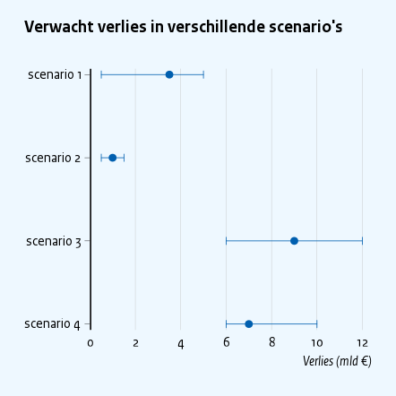

**Relevant parameters:**

| style | no-legend |
| --- | --- |
| type | dot, whisker, whisker |
| title | Verwacht verlies in verschillende scenario’s |
| y_title | Verlies (mld €) |
| turn | y |
| dot_size | 0.7 |
| whisker_col | endeavour |

**How to reproduce this figure:** copy this xlsx-file and this batch file to a personal directory and start the batch file. You can also run this R-script in R.

Parameter `whisker_series` indicates to which series the whisker(s) belong. This is important for the following three reasons. First it determines the position of the whisker in the legend. Second for a barplot this parameter is crucial for the *x*-position of the whiskers. In the following figure, `whisker_series = 2` makes sure that the whisker is shown on top of the second time series (*i.e.* the right-hand bar). Third, in case of a plot that contains bars with whiskers, James will automatically limit the width of the whiskers to the width of the corresponding bars (manually adaptable by parameter `whisker_edge_length`), which prevents whiskers to overlap with each other.

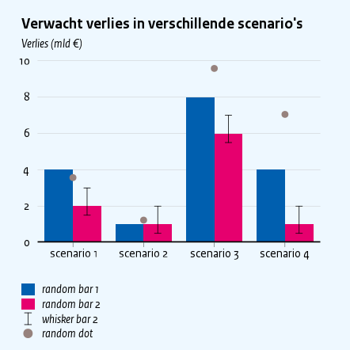

**Relevant parameters:**

| type | bar–, bar–, dot, whisker, whisker |
| --- | --- |
| title | Verwacht verlies in verschillende scenario’s |
| y_title | Verlies (mld €) |
| dot_size | 0.7 |
| legend_n_per_column | 4 |
| whisker_series | 2 |

**How to reproduce this figure:** copy this xlsx-file and this batch file to a personal directory and start the batch file. You can also run this R-script in R.

Parameter `whisker_legend_show_n` determines the number of whiskers the legend shows - which you may want if different whiskers have different meanings.

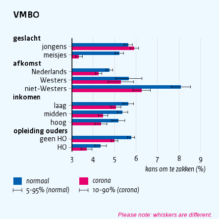

**Relevant parameters:**

| type | bar–, bar–, whisker, whisker, whisker, whisker |
| --- | --- |
| title | VMBO |
| y_title | kans om te zakken (%) |
| footnote | Please note: whiskers are different. |
| footnote_col | rose |
| turn | y |
| legend_n_per_column | 2 |
| whisker_legend_show_n | 2 |

**How to reproduce this figure:** copy this xlsx-file and this batch file to a personal directory and start the batch file. You can also run this R-script in R.

List of figures with whiskers: Impact no-deal Brexit (horizontal), Impact no-deal Brexit (tall), VMBO, Verwacht verlies in verschillende scenario’s, Verwacht verlies in verschillende scenario’s.

### 3.6.1 Tailor your whiskers

- **`whisker_col`**: not documented yet. The value is of type ‘string’. For the *default* style the value is `black`. Figure(s) using ‘whisker_col’: Verwacht verlies in verschillende scenario’s.
- **`whisker_edge_length`**: not documented yet. The value is of type ‘numeric’. Unit: ‘cm’. For the *default* style the value is `7.0000000000000007E-2`.
- **`whisker_legend_show_n`**: the number of whiskers you want to show in your legend. If different whiskers for different series have different meanings, you may want to show them all. If you don’t want to see whiskers in your legend, then set whisker_legend_show_n = 0. Please note that you can change the order of the whiskers in your data if needed. The value is of type ‘numeric’. Example(s): `0, 1, 2, …`. For the *default* style the value is `1`. Figure(s) using ‘whisker_legend_show_n’: Impact no-deal Brexit (horizontal), Impact no-deal Brexit (tall), VMBO.
- **`whisker_lwd`**: not documented yet. The value is of type ‘numeric’. For the *default* style the value is `0.5`.
- **`whisker_series`**: time series which this series corresponds to. The default value is set so that your first whisker definition is superimposed on the first time series (bar–), the second on the second, etc. If, for example, you have a whisker for only one of the time series, you can indicate here which time series that is. The value is a list with elements of the type ‘numeric’ separated by ‘,’. For the *default* style the value is `1, 2, 3, 4, 5, 6, 7, 8, 9, 10`. Figure(s) using ‘whisker_series’: Verwacht verlies in verschillende scenario’s.

## 3.7 Combining the above types

You can combine different types in one plot. Parameter `name_col` colors the line black. Section Colors discusses how to use this paramter.

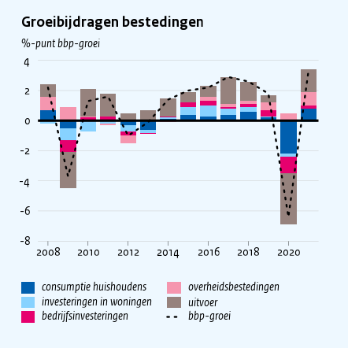

**Relevant parameters:**

| type | bar=, bar=, bar=, bar=, bar=, line |
| --- | --- |
| title | Groeibijdragen bestedingen |
| y_title | %-punt bbp-groei |
| name_col | bbp-groei=black |
| line_lty | 3 |

**How to reproduce this figure:** copy this xlsx-file and this batch file to a personal directory and start the batch file. You can also run this R-script in R.

## 3.8 Geographic map with colored regions

This section explains how to create a figure with a geographic map of different regions, each with a given color. A color may be either given directly or be interpolated based on a given value.

The following box provides *an overview* of the [type of regions of The Netherlands](https://www.cbs.nl/nl-nl/dossier/nederland-regionaal/geografische-data/cbs-gebiedsindelingen) you can choose from:

Arbeidsmarktregio, Arrondissementsgebied, Brandweerregio, Buurt, COROP-gebied, COROP-plusgebied, COROP-subgebied, Gemeente, GGD-regio, Grootstedelijke aglomeratie, Jeugdregio, Kamer van Koophandelregio, Landbouwgebied, Landbouwgroep, Landsdeel, NUTS1, NUTS2, NUTS3, Politieregio, Provincie, Regionaalmeld Coordinatiepunt, Regionale Eenheid, RES-regios, Ressort, RPA-gebied, Stadsgewest, Toeristengebied, Toeristengroep, Veiligheidsregio, Veiligthuisregio, Wijk, Zorgkantoorregio.

Downloaded July 16, 2020. These items are available for different years.

The following subsections explain step by step how to start creating your own custom geographic map.

### 3.8.1 Step 1: choose a map

You start with selecting a specifc map from Appendix: CBS Geo-regions and assign that value to parameter `geo_cbs_map`. Next, with parameter `style` you indicate that you want to create a map. As last, you set parameter `tab` to a non-existing data tab. For example, your meta-tab could look as follows.

| parameter | value |
| --- | --- |
| `tab` | data |
| `style` | map |
| `geo_cbs_map` | arbeidsmarktregio_2020 |

Doing so will result in a map that divides The Netherlands in so-called *arbeidsmarktregio’s* in the year 2020.

### 3.8.2 Step 2: save file and create figure

After saving your file, you can run James for the first time. If the tab you refer to does not exist yet (*important!*), James will create a new tab with the given name, fill it with data (see next step) and create the following figure.

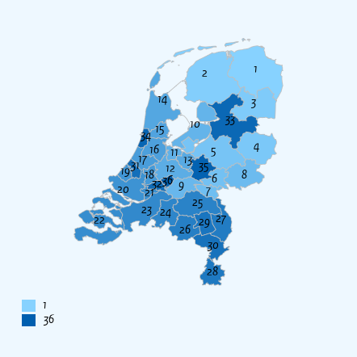

**Relevant parameters:**

| style | map |
| --- | --- |
| geo_cbs_map | arbeidsmarktregio_2020 |

**How to reproduce this figure:** copy this xlsx-file and this batch file to a personal directory and start the batch file. You can also run this R-script in R.

### 3.8.3 Step 3: initialisation of the data tab (re-open xlsx-file)

After running James, you can find the freshly created data tab after closing and re-opening your xlsx file. In the data tab, you’ll find three columns:

- `region` with the region names for the chosen `geo_cbs_map`
  - each region listed here will be shown
  - you can manually remove regions later
- `value` with a unique integer for each region
  - you can remove the values or update them later, according to which the regions will be colored
  - the subsection below will explain how you can ‘hardcode’ a color for a given region
- `label` with numbers 1, 2, … as an example label for each region
  - you can remove or update the labels later

To be complete, there is one more column which you can add too (not yet present):

- `color` so you can ‘manually’ set colors
  - the xlsx-file of the next figure uses a color column to give color `sun` to region `Zeeland`
  - you can open the respective xlsx-file to see how this is done